# Lab Assignment 7

Dylan Berneman

2023-05-19

### Question 1

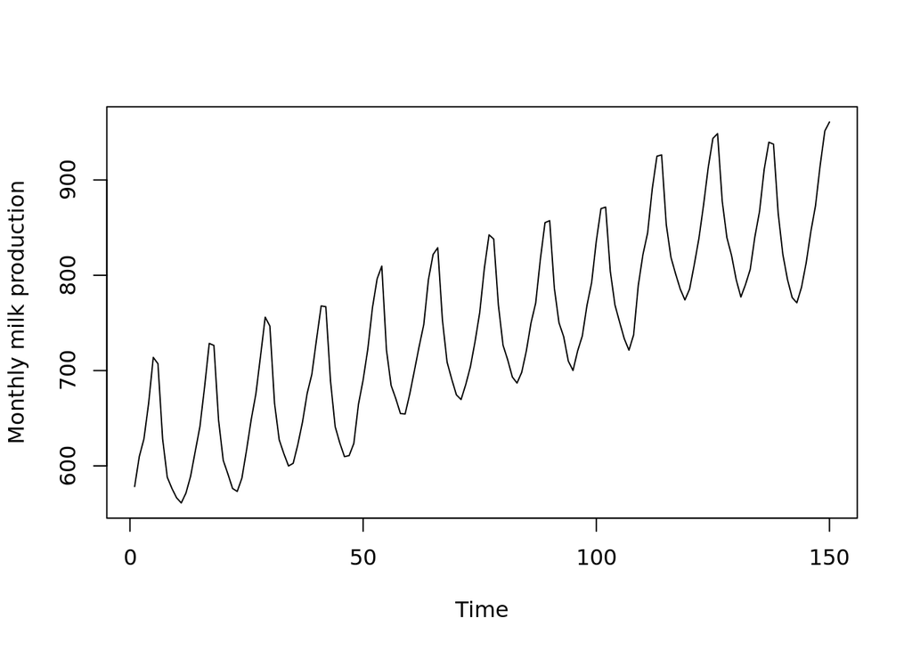

```r
milk <- subset(tsdl, 12, "Agriculture")[[3]]
train <- milk[1:150]
test <- milk[151:156]
ts.plot(train, ylab = "Monthly milk production")
```

From the above graph, we can conclude that X<sub>t</sub> is non-stationary because of the upward trend and seasonality. (You can think about whether we need to transform the series or not.) To make it more stationary, we need to remove trend and seasonality with the following code:

```r
dmilk <- diff(train, 12)
ddmilk <- diff(dmilk, 1)
```

Let Y<sub>t</sub> denote the series ddmilk. Then, Y<sub>t</sub> = (1 − B)(1 − B<sup>12</sup>)X<sub>t</sub>. As Lab Assignment 5, we can use SARIMA(0, 1, 0) × (1, 1, 1)<sub>12</sub>. Now, we will conduct model diagnostic analysis.

```r
fit.i <- sarima(xdata=train, p=0, d=1, q=0, P=1, D=1, Q=1, S=12)
```

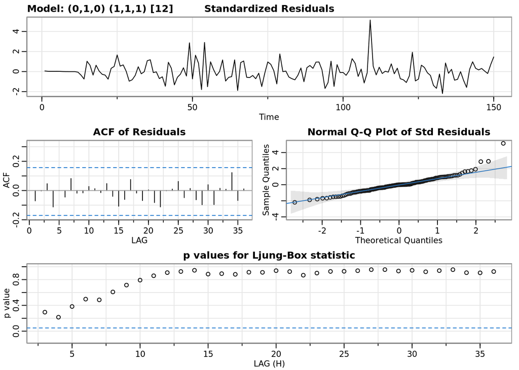

1. Perform diagnostics on the chosen model fit. Do the residuals appear to be white noise? Are they normally distributed? You should conduct hypothesis testing and plot some graphs to answer this questions. (You can think about why we want to check normality of the residuals.)

```r
res <- fit.i$fit$residuals
mean(res)
```

```
## [1] 0.03021635
```

```r
var(res)
```

```
## [1] 31.89208
```

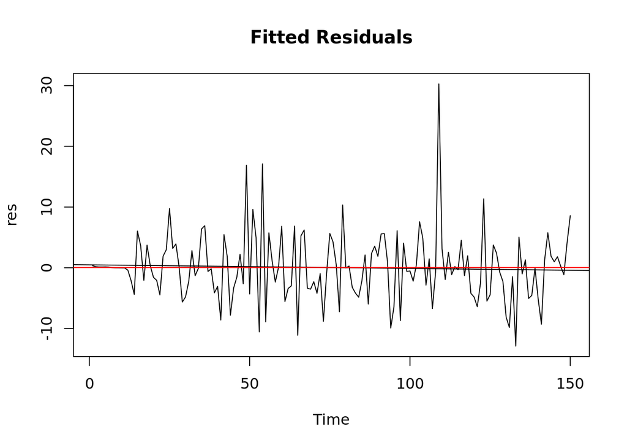

```r
par(mfrow=c(1, 1))
ts.plot(res, main="Fitted Residuals")
t <- 1:length(res)
fit.res = lm(res~ t)
abline(fit.res)
abline(h = mean(res), col = "red")
```

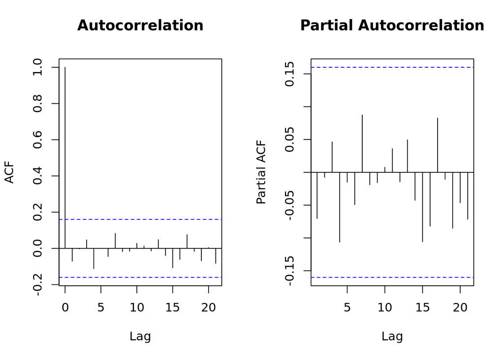

```r
# ACF and PACF:
par(mfrow=c(1, 2))
acf(res, main="Autocorrelation")
pacf(res, main="Partial Autocorrelation")
```

```r
# Test for independence of residuals
Box.test(res, lag = 9, type = c("Box-Pierce"), fitdf = 1)
```

```
##
##  Box-Pierce test
##
## data:  res
## X-squared = 4.3594, df = 8, p-value = 0.8233
```

```r
Box.test(res, lag = 9, type = c("Ljung-Box"), fitdf = 1)
```

```
##
##  Box-Ljung test
##
## data:  res
## X-squared = 4.55, df = 8, p-value = 0.8044
```

```r
res2 = res^2
Box.test(res2, lag = 9, type = c("Ljung-Box"), fitdf = 0)
```

```
##
##  Box-Ljung test
##
## data:  res2
## X-squared = 1.4928, df = 9, p-value = 0.9972
```

```r
# Test for normality of residuals
shapiro.test(res)
```

```
##
##  Shapiro-Wilk normality test
##
## data:  res
## W = 0.93109, p-value = 1.183e-06
```

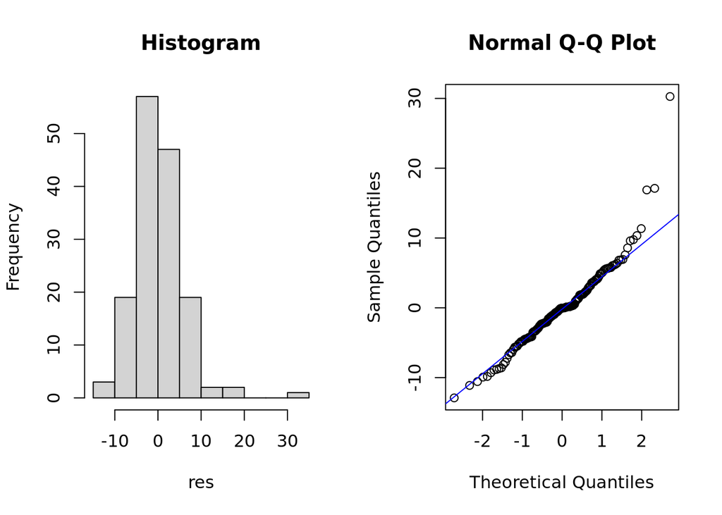

```r
# Histogram and QQ-plot:
par(mfrow=c(1,2))
hist(res,main = "Histogram")
qqnorm(res)
qqline(res,col ="blue")
```

2. Forecast the next 6 observations using sarima.for(), and plot your predictions. And you should also add true milk prodcution points in test.

```r
forecast <- sarima.for(train, n.ahead=6, p=0, d=1, q=0, P=1, D=1, Q=1, S=12)
```

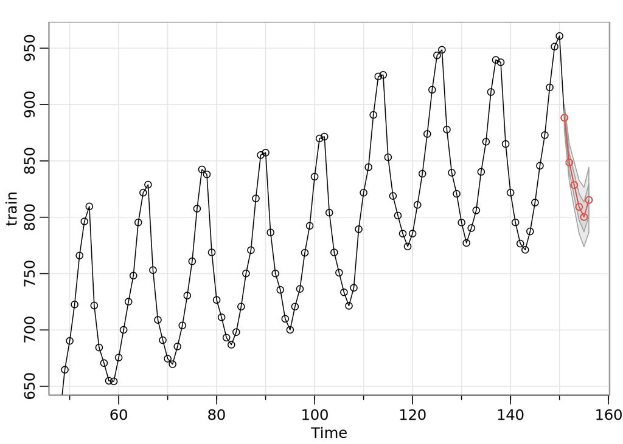

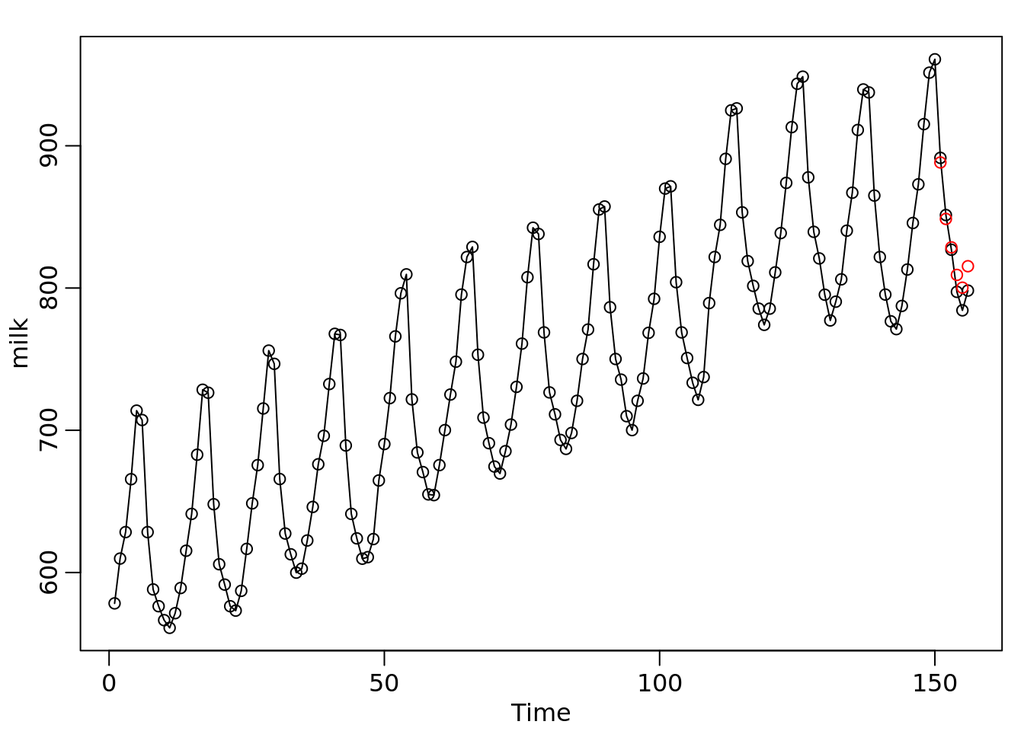

```r
milk.pred=milk
milk.pred[151:156]=forecast$pred


plot(x=c(1:156), y=milk, xlab="Time")
lines(x=c(1:156), y=milk)
points(forecast$pred, col="red")
```

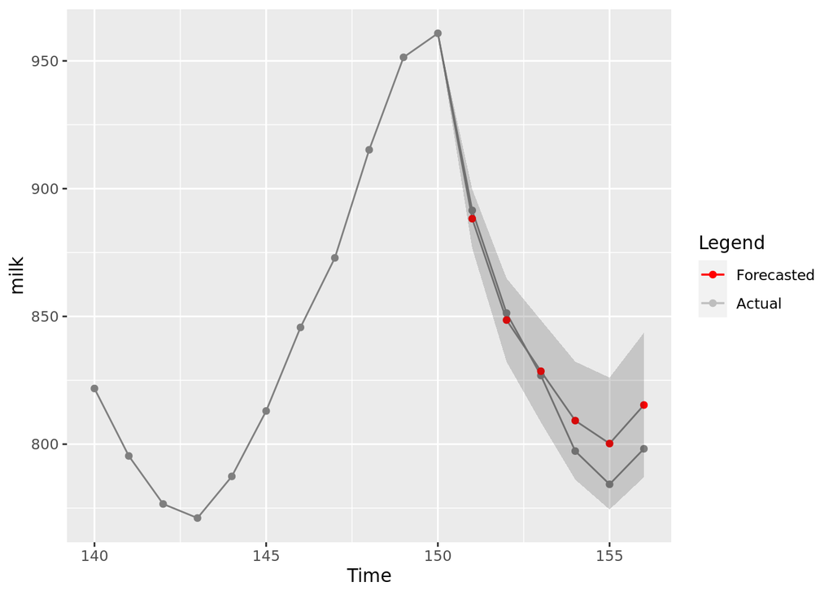

```r
data=data.frame("Time"=c(1:156), milk)

forecast=data.frame(forecast)

forecast<- forecast%>%
  mutate("lcl" = forecast$pred - 1.96*forecast$se)
forecast<- forecast%>%
  mutate("ucl" = forecast$pred + 1.96*forecast$se)
forecast["Time"] = c(151:156)

frame = data.frame(matrix(ncol=5, nrow=1))
colnames(frame) = colnames(forecast)
frame[1, 1:5] <- c(data$milk[150], 0, data$milk[150], data$milk[150], data$Time[150])
forecast =  rbind(frame, forecast)

colors <- c("Forecasted" = "red", "Actual" = "grey")
ggplot(data[140:156, 1:2], aes(Time, milk, color="grey")) + geom_line() + geom_point() + geom_line(data = forecast, aes(x=Time, y= pred, color="red")) + geom_point(data = forecast[2:7, 1:5], aes(x=Time, y= pred), color="red") + geom_ribbon(data = forecast, aes(x=Time, y=pred, ymin=lcl, ymax=ucl), color=NA, alpha=.2)+labs(color="Legend") + scale_color_manual(values = colors)
```